# SISMID Spatial Statistics

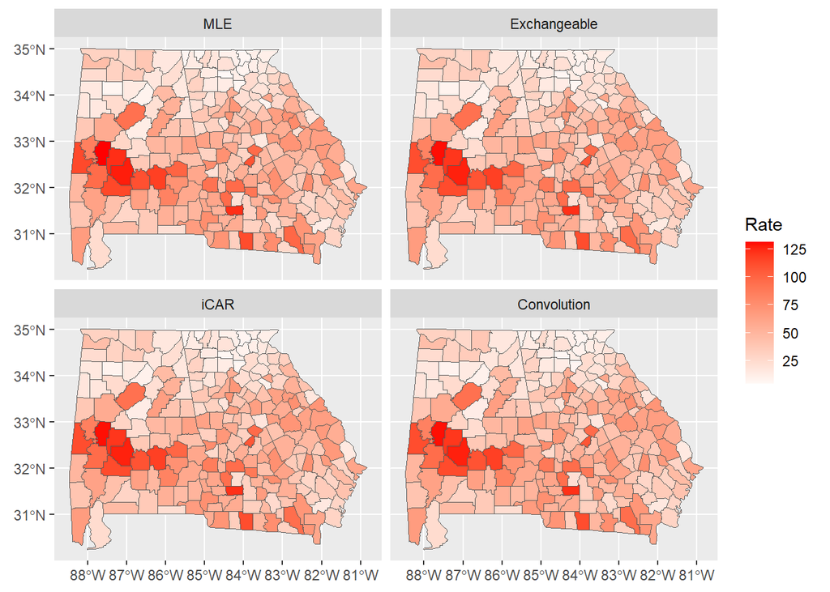

```r
plot.dat = data.frame (FIPS = dat.areal$FIPS,
                  type =rep(c("MLE", "Exchangeable", "iCAR", "Convolution"), each = nrow (dat.areal)),
                  rr = c(as.matrix(st_drop_geometry(dat.areal[,c("rr.mle", "rr.exch", "rr.iCAR", "rr.conv")]))))
plot.dat$type = factor(plot.dat$type, levels = c("MLE", "Exchangeable", "iCAR", "Convolution"))
plot.dat = merge (dat.areal, plot.dat, by = "FIPS")
ggplot () + geom_sf (data = plot.dat, aes (fill = rr)) + facet_wrap(~type)+
  scale_fill_gradient2(low = "white",high = "red", name = "Rate")
```

Let’s just compare the convoluation model and the naive estimates. We see that the larger differences in county-specific relative risks are observed in counties with less cases and smaller population. The difference in precision (measured by the standard error of relative estimates) also depends on population and case number.

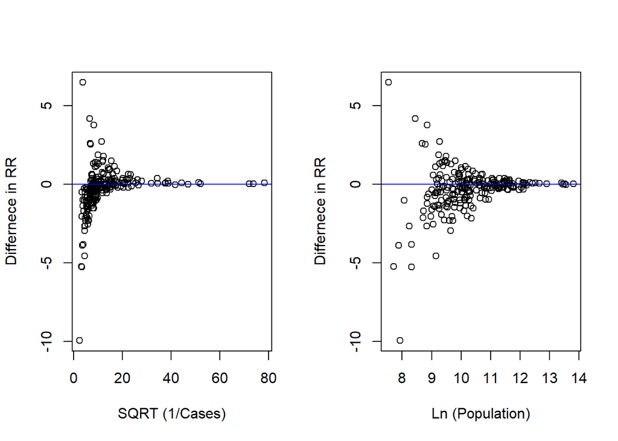

```r
par (mfrow=c(1,2))
plot ( sqrt (Y), dat.areal$rr.mle - dat.areal$rr.conv,
       ylab = "Differnece in RR", xlab = "SQRT (1/Cases)"); abline (0,0, col = "blue")
plot ( log(P), dat.areal$rr.mle - dat.areal$rr.conv,
       ylab = "Differnece in RR", xlab = "Ln (Population)"); abline (0,0, col = "blue")
```

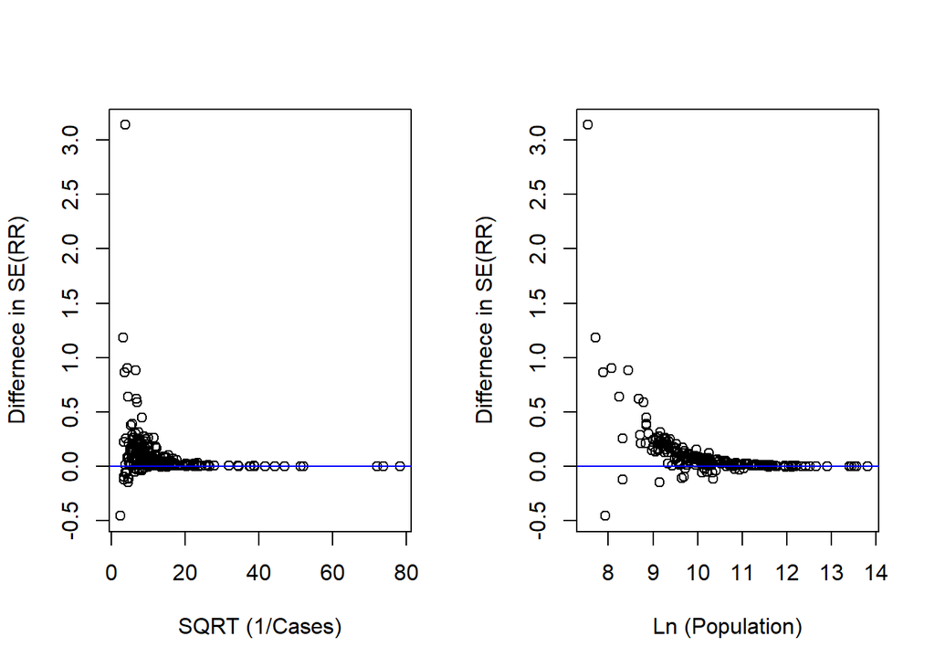

```r
par (mfrow=c(1,2))
plot ( sqrt (Y), dat.areal$se.mle - dat.areal$se.conv,
       ylab = "Differnece in SE(RR)", xlab = "SQRT (1/Cases)"); abline (0,0, col = "blue")
plot ( log(P), dat.areal$se.mle - dat.areal$se.conv,
       ylab = "Differnece in SE(RR)", xlab = "Ln (Population)"); abline (0,0, col = "blue")
```

Finally, let’s add household meduab income as a spatial covariate. We see that the spatial model gives a stronger negative association between income and chlamydia rates. The standard error is also much larger compared to a standard Poisson regression.

```r
dat.areal$Income_center = (dat.areal$Income-mean (dat.areal$Income))/1000
fit = inla (Cases~Income_center+f(areal_ID, model = "besag", graph = G) +
                   f(areal_ID_2), E= Population, family = "poisson", data = dat.areal,control.compute = list(dic = TRUE, waic = TRUE))

summary (fit)
```

```
## Time used:
##     Pre = 0.196, Running = 0.222, Post = 0.053, Total = 0.471
## Fixed effects:
##                 mean    sd 0.025quant 0.5quant 0.975quant   mode kld
## (Intercept)   -5.564 0.018     -5.600   -5.564     -5.529 -5.564   0
## Income_center -0.034 0.005     -0.043   -0.034     -0.024 -0.034   0
##
## Random effects:
##   Name     Model
##     areal_ID Besags ICAR model
##    areal_ID_2 IID model
##
## Model hyperparameters:
##                           mean     sd 0.025quant 0.5quant 0.975quant  mode
## Precision for areal_ID    1.56  0.469      0.773     1.52       2.59  1.44
## Precision for areal_ID_2 23.54 16.481      7.239    19.05      67.64 13.14
##
## Deviance Information Criterion (DIC) ...............: 1916.89
## Deviance Information Criterion (DIC, saturated) ....: 437.68
## Effective number of parameters .....................: 210.18
##
## Watanabe-Akaike information criterion (WAIC) ...: 1868.73
## Effective number of parameters .................: 116.21
##
## Marginal log-Likelihood:  -1416.85
##  is computed
## Posterior summaries for the linear predictor and the fitted values are computed
## (Posterior marginals needs also 'control.compute=list(return.marginals.predictor=TRUE)')
```

```r
prec_to_var(fit$marginals.hyperpar[[1]])
```

```
##        mean        sd quant0.025 quant0.25 quant0.5 quant0.75 quant0.975
## 1 0.7030575 0.2319379  0.3867575 0.5379749 0.654686 0.8175147   1.284356
```

```r
prec_to_var(fit$marginals.hyperpar[[2]])
```

```
##         mean         sd quant0.025  quant0.25   quant0.5  quant0.75 quant0.975
## 1 0.05895053 0.03213932 0.01490998 0.03503742 0.05308125 0.07613069   0.137204
```

```r
##Compare to other GLM
dat.areal$logPop = log(dat.areal$Population)
summary (glm (Cases~offset (logPop) + Income_center, family = "poisson", data = dat.areal))
```

```
##
## Call:
## glm(formula = Cases ~ offset(logPop) + Income_center, family = "poisson",
##     data = dat.areal)
##
## Coefficients:
##                 Estimate Std. Error  z value Pr(>|z|)
## (Intercept)   -5.1873009  0.0043950 -1180.27   <2e-16 ***
## Income_center -0.0228930  0.0003785   -60.49   <2e-16 ***
## ---
## Signif. codes:  0 '***' 0.001 '**' 0.01 '*' 0.05 '.' 0.1 ' ' 1
##
## (Dispersion parameter for poisson family taken to be 1)
##
##     Null deviance: 21775  on 225  degrees of freedom
## Residual deviance: 17893  on 224  degrees of freedom
## AIC: 19376
##
## Number of Fisher Scoring iterations: 4
```

```r
summary (glm (Cases~offset (logPop) + Income_center, family = "quasipoisson", data = dat.areal))
```

```
##
## Call:
## glm(formula = Cases ~ offset(logPop) + Income_center, family = "quasipoisson",
##     data = dat.areal)
##
## Coefficients:
##                Estimate Std. Error  t value Pr(>|t|)
## (Intercept)   -5.187301   0.038599 -134.390  < 2e-16 ***
## Income_center -0.022893   0.003324   -6.888 5.66e-11 ***
## ---
## Signif. codes:  0 '***' 0.001 '**' 0.01 '*' 0.05 '.' 0.1 ' ' 1
##
## (Dispersion parameter for quasipoisson family taken to be 77.13112)
##
##     Null deviance: 21775  on 225  degrees of freedom
## Residual deviance: 17893  on 224  degrees of freedom
## AIC: NA
##
## Number of Fisher Scoring iterations: 4
```

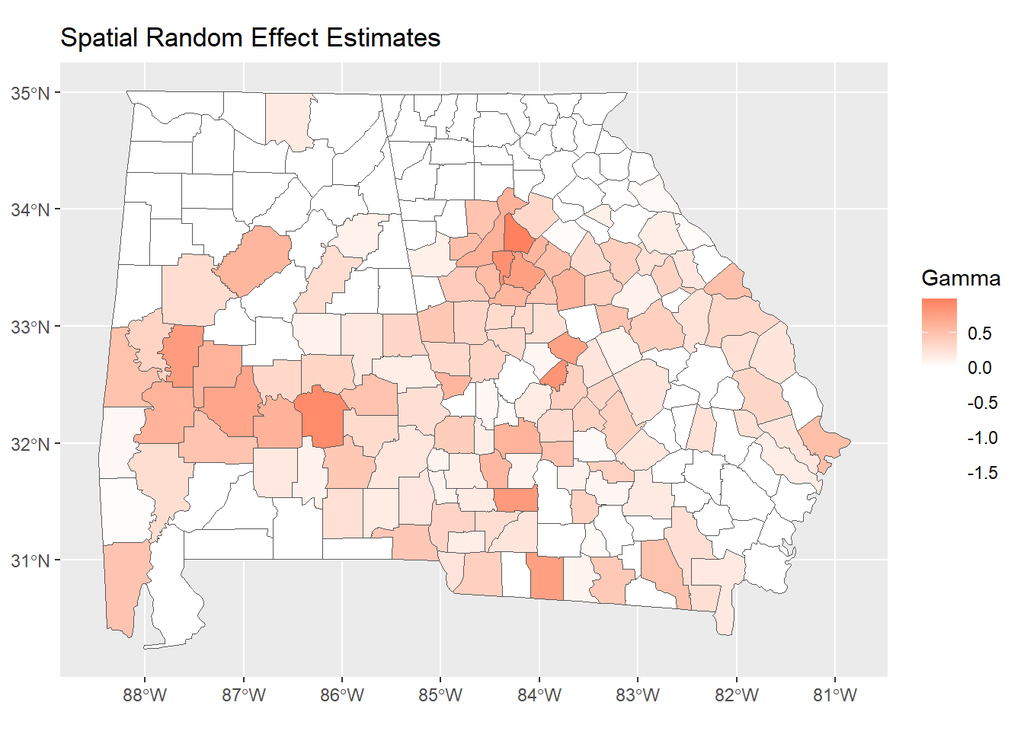

```r
#Examine random effects from the model
dat.areal$gamma_est = fit$summary.random[[1]]$mean
dat.areal$gamma_se = fit$summary.random[[1]]$sd
dat.areal$theta_est = fit$summary.random[[2]]$mean
dat.areal$theta_se = fit$summary.random[[2]]$sd
ggplot () + geom_sf (data = dat.areal, aes (fill = gamma_est))+
  scale_fill_gradient2(low = "white",high = "red", name = "Gamma")+ggtitle("Spatial Random Effect Estimates")
```

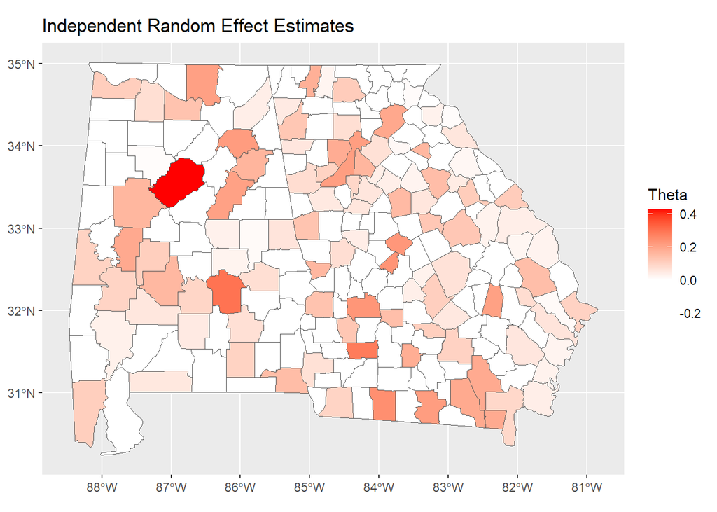

```r
ggplot () + geom_sf (data = dat.areal, aes (fill = theta_est))+
  scale_fill_gradient2(low = "white",high = "red", name = "Theta")+ggtitle("Independent Random Effect Estimates")
```